# Your Digest for Friday, Sep 22, 2023 11:59 PM

#### Immunologic staining patterns

> [!TIP] Mnemonic: granular - MPM

| Linear | Granular |
| --- | --- |
| Seen with anti GBM *antibodies* | Seen with *immune complexes* OR with *antibodies to against **certain glomerular components*** |
| Good pasture syndrome wtih Deposition of anti GBM 🚩antibodies🚩 | membranoproliferative - subendothelial **immune complexes** |
|  | Post infectious - subepithelial **IgG and comlement complexes** |
|  | membranous - subepithelial and intramembranous **immune complexes** |

Polygenic inheritance pattern -

- genes but possible env factor interact to produce Parkinson's disease.
- Majority of cases are **sporadic.**
- but #autosomalDominant and #autosomal-Recessive forms of the disease also exist, although rare.
- Autosomal dominant PD is caused by mutations of the alpha synuclein gene.

**Pathogenesis:** Loss of *dopaminergic neurons* in pars compacta of substantia nigra of **midbrain** *which project* to the **striatum** (= caudate nucleus + putamen) of the basal ganglia. 70% loss has occured when symptoms appear.

> [!INFO] The nigrostriatal pathway

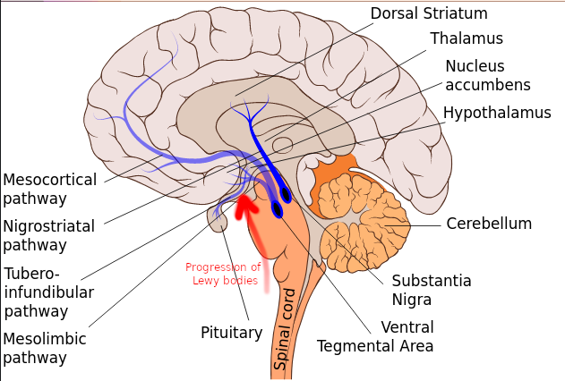

> One of the 4 major domapinergic pathways in the brain. [Source](https://en.wikipedia.org/wiki/Nigrostriatal_pathway)

**Pathology:**

- **Lewy bodies** (neuronal inclusions made of alpha-synuclein and ubiquitin) seen first in medulla -> pons -> substantia nigra.
- palor of the substantia nigra
- Lewy neurites (dystrophic neurites contained the inclusions)

[figure not shown]

> [!WARNING]  
> 🚩None of the drugs in Parkinson's alter disease progression.

| Drug | Mechanism | Clinical context | Side effects |
| --- | --- | --- | --- |
| Levodopa | Dopamine - crosses BBB | most effective drug; siginificant improv. initially but effect wears off | Choreiform movements, wearing off (duration of action of a dose becomes shorter) and *on/off effects* with prolonged Rx |
| ==Benserazide== (cobeneldopa) |  |  |  |
| ==carbidopa== (cocareldopa) | ==Both== are **dopa decarboxylase inhibitors** | combined with levodopa to reduce side effects |  |
| Dopamine agonists (pramipexole) |  |  |  |
| Selegiline / rasagiline | MAO - inhibit dopamine breakdown |  |  |
| Amantadine | Enhances dopamine release | Modest effect - used in **advanced disease** to improve diskinesia |  |
| Antimuscarinics (orphenadrine) |  | used to reduce tremmor in *younger* patients as confusion can occur in older patients |  |
| Entacapone | Catachol-O-methyltransferase inhibitor (prevents peripheral degradation of levodopa) | Prolongs levodopa action - used to manage on/off phenomena; often combined with levodopa |  |
| Apomorphine | Potent dopamine agonist - short acting | **used as rescue therapy** during an 'off' episode |  |
| istradeffyline | prevent peripheral degration of levodopa |  |  |

*Istradeffyline* a medication used as an add-on treatment to [levodopa](https://en.wikipedia.org/wiki/Levodopa)/[carbidopa](https://en.wikipedia.org/wiki/Carbidopa) in adults with [Parkinson's disease](https://en.wikipedia.org/wiki/Parkinson%27s_disease) (PD) experiencing "off" episodes.  
**Deep brain stimulation** is specially useful for severe motor symptoms. (specially in patients with youger onset of disease). Improves diskinesia, seems as effective as levodopa. Trend is towards earlier use before motor symptoms become severe.

# Chronic pancreatitis

#2021BSQ-JUL/Q07

Multiple causes:  
**Alcohol is a common cause**. CKD, Cystic fibrosis, Obstruction, trauma, recurrent acute pancreatitis, hypercalcemia, autoimmune are all causes. [Source](https://www.rcpa.edu.au/Manuals/RCPA-Manual/Pathology-Tests/P/Pancreatic-elastase-faeces)

There is loss of endocrine and exocrine function but significant failure occurs only after many years.

- Exocrine failure is not clinically apparent until 90% of the pancreas is destroyed.

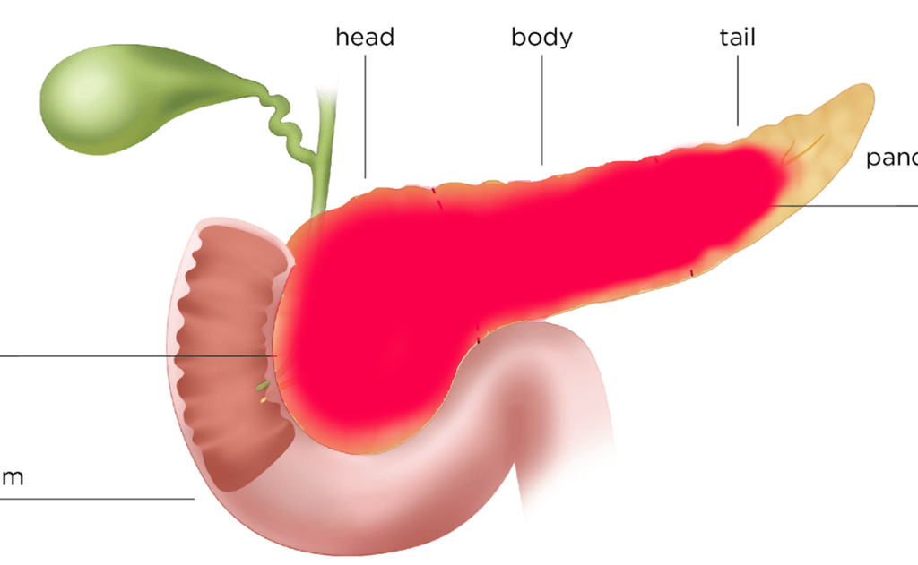

- Occurs either because trypsin is activated before it leaves or is unable to leave once activated.
- Ethanol does this by increasing intracellular calcium which causes trypsin activation but alcohol must be only one factor of many which act together.
- Genetic factors (SPINK, PRSS1) which affect trypisin activation have been implicated in the pathogenesis.
- CFTR gene (Cyctic fibrosis transmembrane conductance regulator) function is required for production of high volume bicarbonate rich pancreatic juice which flushes out trypsin. Therefore, Cystic fibrosis is associated with chronic pancreatitis.
  - In cystic fibrosis patients, pancreatic exocrine insuffiency will develop in utero or the perinatal period. They will develop malabsorption and failure to thrive.
- Autoimmune pancreatitis Type I (the commonest type) is seen in men. IgG4 positive with dense lymphoplasmacytic infiltrate.
  - **Autoimmune pancreatitis responds well to steroids** and lack of response should arouse suspicion of another diagnosis. Azathioprine is used for relapses.

> [!INFO] Mnemonic: Men drink -> pancreatitis common -> autoimmune pancreatitis is also commoner in men

## Investigations in chronic pancreatis

- Elevated serum amylase (in advanced disease, may be normal due to exocrine insufficiency)
- Serum IgG4 levels -> autoimmune panceatitis
- Low faecal elastase
- Abdominal USS
- SPINK, PRSS1 and CFTR gene mutations
- CECT
- MRI and MRCP
- Diagnostic ERCP has been replaced by MRCP

## Management

Smoking is a risk factors -> smoking cessation is recommended in management.

- Pain: NSAIDS, tramadol, coeliac nerve block, TCA antidepressants for chronic pain, pregabalin.
- Steatorrhoea: usually occurs with long standing chronic pancreatitis. Enzyme supplements are given.
  - note that inadequate pancreatic **bicarbonate** secretion also contributes by ?inhibiting enzyme activation in the duodenum
  - Fat intake should NOT be reduced - will only worsen malnutrition.

## Complications

Pancreatic pseudocyst, ascites, pleural effusion, pancreatic cancer.

### Pancreatic diabetes

AKA type 3c diabeties or pancreatogenic diabetes.  
Occurs after many years of disease progression.  
A type of *'brittle' diabetes* : patients have insulin deficiency (but rare ketosis) and also **glucagon deficiency** so they develop hypoglycaemia very easily while on treatment.

# Haematologic changes in pregnancy

#pregnancy  
#2021BSQ-JUL/Q10